# Analysis of Alcohol Consumption across the World

# About this exercise

This code contains analysis of data on consumption of alcohol across the world. (Source: World Health Organisation, Global Information System on Alcohol and Health (GISAH), 2010)

# Analysis

According to WHO, beer was the drink of choice in 2010.The average consumption (per person) of different forms of alcohol - beer, wine and spirits - was:

```
## beer_servings106
## spirit_servings81
## wine_servings49
```

But the consumption of alcohol varies across countries. The histograms of beer, wine and spirit consumption show that in a large number of the countries the consumption of is much lower than the average.

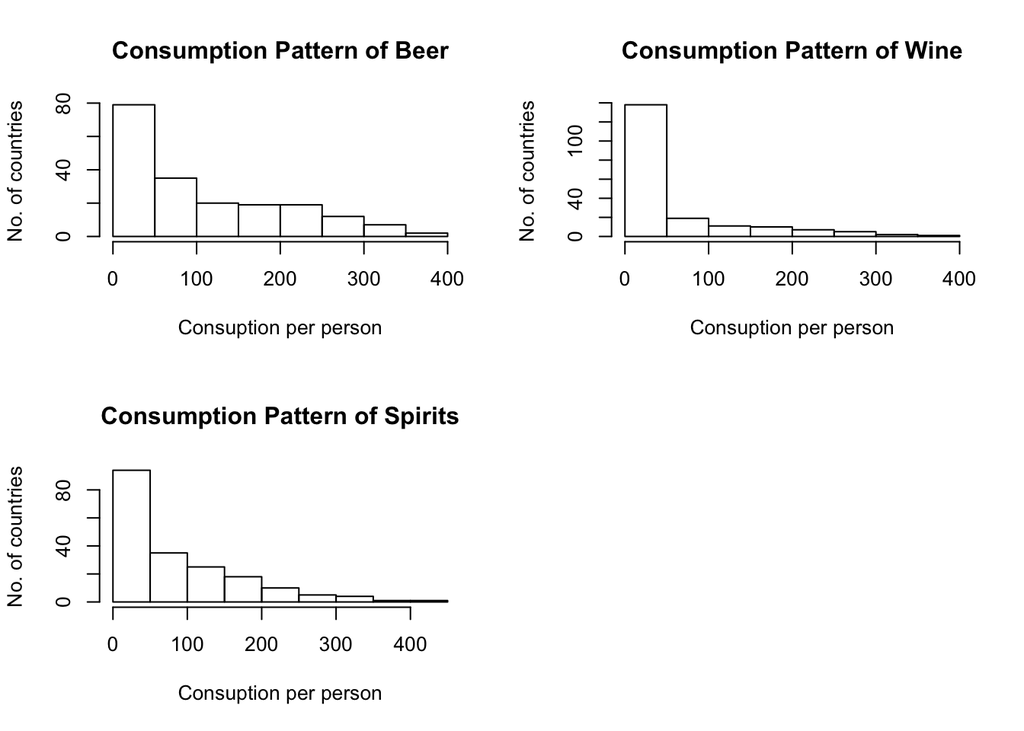

For example, a closer look at the data reveals that the while the average beer consumption across all countries in 2010 was 106.2, it varied from 0 to a maximum of 376. In most countries the consumption per person was only 76.

### **Top 10 countries by consumption**

```
##               country spirit_servings            country beer_servings
## 1             Ireland             118             France           127
## 2          Luxembourg             133            Belarus           142
## 3             Andorra             138           Slovakia           196
## 4              France             151            Grenada           199
## 5      Czech Republic             170         Luxembourg           236
## 6           Lithuania             244            Andorra           245
## 7            Slovakia             293 Russian Federation           247
## 8  Russian Federation             326            Ireland           313
## 9             Belarus             373          Lithuania           343
## 10            Grenada             438     Czech Republic           361
##               country wine_servings
## 1             Grenada            28
## 2             Belarus            42
## 3           Lithuania            56
## 4  Russian Federation            73
## 5            Slovakia           116
## 6      Czech Republic           134
## 7             Ireland           165
## 8          Luxembourg           271
## 9             Andorra           312
## 10             France           370
```